# Analyzing and predicting the number of air passengers

*Made from an initial version prepared by Balázs Kégl (LAL/CNRS), Alex Gramfort (LTCI/Telecom ParisTech), Djalel Benbouzid (UPMC), Mehdi Cherti (LAL/CNRS) for [RAMP](http://www.ramp.studio)*

## Introduction

The data set was donated by an unnamed company handling flight ticket reservations. The data is thin, it contains:

- the date of departure
- the departure airport
- the arrival airport
- the mean and standard deviation of the number of weeks of the reservations made before the departure date
- a field called `log_PAX` which is related to the number of passengers (the actual number were changed for privacy reasons)

The goal is to predict the `log_PAX` column. The prediction quality is measured by RMSE.

**The challenge for this dataset is to perform prediction on flight traffic using learnt regressor**.

```python
%matplotlib inline
import numpy as np
import pandas as pd
import matplotlib.pyplot as plt
from sklearn.preprocessing import PolynomialFeatures
pd.set_option('display.max_columns', None)
```

```python
# optional
import seaborn as sns; sns.set()
```

## Fetch the data and load it in pandas

```python
data = pd.read_csv("public_train.csv")
```

```python
print( min(data['DateOfDeparture']) )
print( max(data['DateOfDeparture']) )
```

```
2011-09-01
2013-03-05
```

```python
data.head()
```

|  | DateOfDeparture | Departure | Arrival | WeeksToDeparture | log_PAX | std_wtd |
| --- | --- | --- | --- | --- | --- | --- |
| 0 | 2012-10-21 | DFW | SFO | 14.600000 | 10.757779 | 11.575837 |
| 1 | 2012-09-13 | LAX | ATL | 14.730769 | 11.808097 | 13.364304 |
| 2 | 2012-09-04 | ORD | IAH | 8.470588 | 10.865349 | 5.885551 |
| 3 | 2012-08-13 | DEN | PHX | 8.200000 | 10.710562 | 6.292853 |
| 4 | 2012-09-10 | ORD | SEA | 12.090909 | 11.498355 | 9.138662 |

```python
print(data['Departure'].unique())
```

```
['DFW' 'LAX' 'ORD' 'DEN' 'MCO' 'IAH' 'MIA' 'ATL' 'LGA' 'SEA' 'PHX' 'CLT'
 'DTW' 'LAS' 'EWR' 'MSP' 'BOS' 'PHL' 'SFO' 'JFK']
```

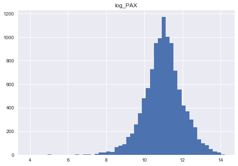

```python
data.hist(column='log_PAX', bins=50);
```

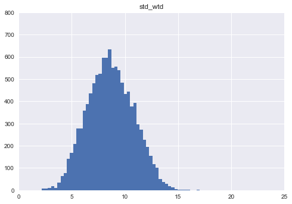

```python
data.hist('std_wtd', bins=50)
plt.xlim(0, 25)
plt.ylim(0, 800)
plt.show()
```

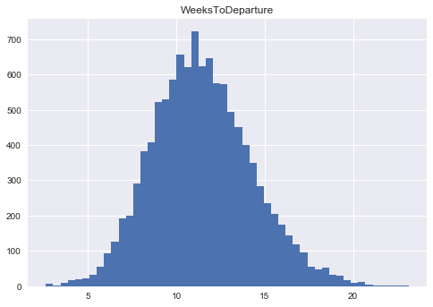

```python
data.hist('WeeksToDeparture', bins=50);
```

```python
data.describe()
```

|  | WeeksToDeparture | log_PAX | std_wtd |
| --- | --- | --- | --- |
| count | 11128.000000 | 11128.000000 | 11128.000000 |
| mean | 11.466842 | 10.997728 | 8.635226 |
| std | 2.807131 | 0.998242 | 2.145805 |
| min | 2.625000 | 3.878108 | 2.160247 |
| 25% | 9.523810 | 10.427055 | 7.109619 |
| 50% | 11.304348 | 11.008268 | 8.582272 |
| 75% | 13.259259 | 11.590093 | 10.162525 |
| max | 23.163265 | 14.224277 | 17.035677 |

```python
print(data.dtypes)
```

```
DateOfDeparture      object
Departure            object
Arrival              object
WeeksToDeparture    float64
log_PAX             float64
std_wtd             float64
dtype: object
```

```python
data.shape
```

```
(11128, 6)
```

```python
print( data['log_PAX'].mean() )
print(  data['log_PAX'].std() )
```

```
10.99772803448557
0.9982419545897369
```

## Preprocessing for prediction

Getting dates into numerical columns is a common operation when time series are analyzed with non-parametric predictors. The code below makes all possible choices: ordered columns for the year, month, day, weekday, week, and day in the year, and one-hot columns for year month, day, weekday, and week.

The departure and arrival airports are also converted into one-hot columns.

```python
data_encoded = data

data_encoded = data_encoded.join(pd.get_dummies(data_encoded['Departure'], prefix='d'))
data_encoded = data_encoded.join(pd.get_dummies(data_encoded['Arrival'], prefix='a'))
data_encoded = data_encoded.drop('Departure', axis=1)
data_encoded = data_encoded.drop('Arrival', axis=1)

# following http://stackoverflow.com/questions/16453644/regression-with-date-variable-using-scikit-learn
data_encoded['DateOfDeparture'] = pd.to_datetime(data_encoded['DateOfDeparture'])
data_encoded['year'] = data_encoded['DateOfDeparture'].dt.year
data_encoded['month'] = data_encoded['DateOfDeparture'].dt.month
data_encoded['day'] = data_encoded['DateOfDeparture'].dt.day
data_encoded['weekday'] = data_encoded['DateOfDeparture'].dt.weekday
data_encoded['week'] = data_encoded['DateOfDeparture'].dt.week
data_encoded['n_days'] = data_encoded['DateOfDeparture'].apply(lambda date: (date - pd.to_datetime("1970-01-01")).days)

data_encoded = data_encoded.join(pd.get_dummies(data_encoded['year'], prefix='y'))
data_encoded = data_encoded.join(pd.get_dummies(data_encoded['month'], prefix='m'))
data_encoded = data_encoded.join(pd.get_dummies(data_encoded['day'], prefix='d'))
data_encoded = data_encoded.join(pd.get_dummies(data_encoded['weekday'], prefix='wd'))
data_encoded = data_encoded.join(pd.get_dummies(data_encoded['week'], prefix='w'))
```

```python
data_encoded.tail(5)
```

|  | DateOfDeparture | WeeksToDeparture | log_PAX | std_wtd | d_ATL | d_BOS | d_CLT | d_DEN | d_DFW | d_DTW | d_EWR | d_IAH | d_JFK | d_LAS | d_LAX | d_LGA | d_MCO | d_MIA | d_MSP | d_ORD | d_PHL | d_PHX | d_SEA | d_SFO | a_ATL | a_BOS | a_CLT | a_DEN | a_DFW | … |
| --- | --- | --- | --- | --- | --- | --- | --- | --- | --- | --- | --- | --- | --- | --- | --- | --- | --- | --- | --- | --- | --- | --- | --- | --- | --- | --- | --- | --- | --- | --- |
| 11123 | 2011-11-22 | 11.636364 | 10.334322 | 8.888438 | 0 | 0 | 0 | 0 | 0 | 0 | 0 | 1 | 0 | 0 | 0 | 0 | 0 | 0 | 0 | 0 | 0 | 0 | 0 | 0 | 0 | 0 | 0 | 0 | 0 | … |
| 11124 | 2011-12-14 | 13.541667 | 12.459632 | 10.341891 | 0 | 0 | 0 | 0 | 0 | 0 | 0 | 0 | 0 | 0 | 0 | 0 | 0 | 0 | 0 | 1 | 0 | 0 | 0 | 0 | 0 | 0 | 0 | 0 | 1 | … |
| 11125 | 2013-01-28 | 5.583333 | 11.381124 | 3.752777 | 0 | 0 | 1 | 0 | 0 | 0 | 0 | 0 | 0 | 0 | 0 | 0 | 0 | 0 | 0 | 0 | 0 | 0 | 0 | 0 | 0 | 0 | 0 | 0 | 0 | … |
| 11126 | 2011-09-03 | 12.730769 | 11.308812 | 7.997788 | 0 | 0 | 0 | 0 | 0 | 0 | 0 | 0 | 0 | 1 | 0 | 0 | 0 | 0 | 0 | 0 | 0 | 0 | 0 | 0 | 0 | 0 | 0 | 0 | 0 | … |
| 11127 | 2012-09-24 | 14.250000 | 11.619697 | 9.508768 | 0 | 0 | 0 | 1 | 0 | 0 | 0 | 0 | 0 | 0 | 0 | 0 | 0 | 0 | 0 | 0 | 0 | 0 | 0 | 0 | 0 | 0 | 0 | 0 | 0 | … |

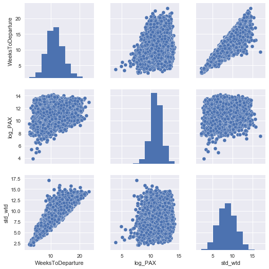

```python
sns.pairplot(data_encoded[data_encoded.columns[[1, 2, 3]]])
plt.show()
```

As expected, there is no clear relation between log_PAX the other two principal variables wtd and std_wtd (second row of the pairplot above).

# Linear Regression

## A linear regressor baseline

We drop the target column and the original data column.

```python
features = data_encoded.drop(['log_PAX','DateOfDeparture'], axis=1)
X_columns = data_encoded.columns.drop(['log_PAX','DateOfDeparture'])
X = features.values
y = data_encoded['log_PAX'].values
```

```python
from sklearn.model_selection import train_test_split

X_train, X_test, y_train, y_test = train_test_split(
    X, y, test_size=0.2, random_state=42)
```

We compare linear regression and Ridge regression (linear regression with regularization of the parameters). Since the cost function for a Ridge Regression is $\left|\left|Xw-y\right|\right|^2_2+\alpha\left|\left|w\right|\right|^2_2$, the parameters must have to be scaled so that each feature is equally represented in the regularization term.

```python
%%time

from sklearn.linear_model import LinearRegression, Ridge
from sklearn.decomposition import PCA
from sklearn.model_selection import cross_val_score
from sklearn.preprocessing import StandardScaler
from sklearn.pipeline import Pipeline

stda_lin = StandardScaler()
stda_rid = StandardScaler()

lin_reg = LinearRegression()
rid_reg = Ridge(alpha = 1)

pipe_lin = Pipeline([('scaler', stda_lin),('regressor', lin_reg)])
pipe_rid = Pipeline([('scaler', stda_rid),('regressor', rid_reg)])

scores1 = cross_val_score(pipe_lin, X_train, y_train, cv=5, scoring='neg_mean_squared_error')
print("Cross-validation score linear regression: {:.4f} +/-{:.4f}\n".format(
    np.mean(np.sqrt(-scores1)), np.std(np.sqrt(-scores1))))

scores2 = cross_val_score(pipe_rid, X_train, y_train, cv=5, scoring='neg_mean_squared_error')
print("Cross-validation score ridge regression: {:.4f} +/-{:.4f}\n".format(
    np.mean(np.sqrt(-scores2)), np.std(np.sqrt(-scores2))))

pipe_lin.fit(X_train, y_train)
y_pred = pipe_lin.predict(X_test)
rmse1 = np.sqrt(np.mean((y_pred-y_test)**2))
print("Error on test set for linear regression : {} \n".format(rmse1))

pipe_rid.fit(X_train, y_train)
y_pred = pipe_rid.predict(X_test)
rmse2 = np.sqrt(np.mean((y_pred-y_test)**2))
print("Error on test set for ridge regression : {}".format(rmse2))
```

```
Cross-validation score linear regression: 0.6379 +/-0.0165

Cross-validation score ridge regression: 0.6418 +/-0.0161

Error on test set for linear regression : 0.6180115578472509

Error on test set for ridge regression : 0.621587239377247
CPU times: user 1.05 s, sys: 251 ms, total: 1.3 s
Wall time: 986 ms
```

```
Fitting 3 folds for each of 11 candidates, totalling 33 fits
```

```
[Parallel(n_jobs=1)]: Done  33 out of  33 | elapsed:    1.7s finished
```

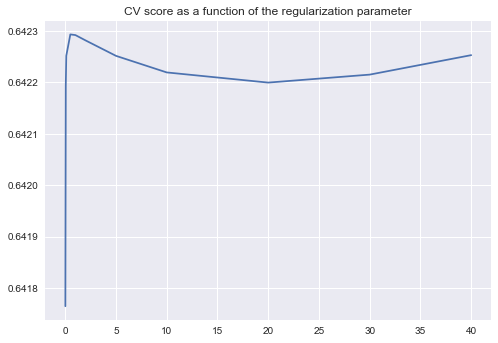

```python
from sklearn.model_selection import GridSearchCV

param_grid = {'regressor__alpha': [0.01, 0.05, 0.1, 0.5, 1, 2, 5, 10, 20, 30, 40]}
gds = GridSearchCV(pipe_rid, param_grid=param_grid, scoring='neg_mean_squared_error', verbose=1)

gds.fit(X_train, y_train)

absi = [i['regressor__alpha'] for i in gds.cv_results_['params']]
plt.plot(absi, np.sqrt(np.float64(np.abs(gds.cv_results_['mean_test_score']))))
plt.title("CV score as a function of the regularization parameter")
plt.show()
```

There doesn't seem to be any significative influence of the regularization parameter on the CV score. And the linear regression without regularization appears to be the best option.

Exercise: Visualize the coefficients, try to make sense of them.

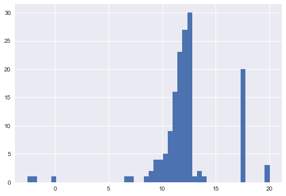

```python
lin_reg.fit(X_train, y_train)
plt.hist(np.log(np.abs(lin_reg.coef_)), 50)
plt.show()
```

The coefficients don't really make sense here because the features aren't scaled and one cefficient isn't going to represent only the relative "sensitivity" of the model to the corresponding feature but also its relative scale.

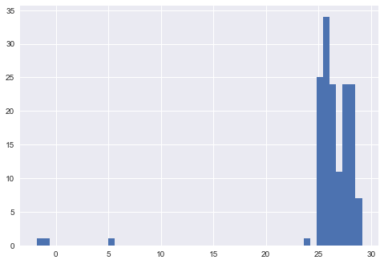

```python
pipe_lin.fit(X_train, y_train)

plt.hist(np.log(np.abs(pipe_lin.get_params()['regressor'].coef_)), 50)
plt.show()
```

Very few parameters have a really small influence on the model and the others have a somehow homogenous contribution to the prediction.

## Comparison of Linear and Ridge Regression

To visualize the errors of the model we plot the prediction as a function of the projected features.

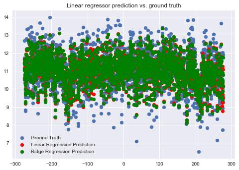

```python
pipe_lin.fit(X_train, y_train)

pipe_rid.fit(X_train, y_train)

pca = PCA(n_components=1)
X_proj = pca.fit_transform(X_test)
y_pred_lin = pipe_lin.predict(X_test)
y_pred_rid = pipe_rid.predict(X_test)
plt.scatter(X_proj, y_test, label='Ground Truth')
plt.scatter(X_proj, y_pred_lin, color='r', label='Linear Regression Prediction')
plt.scatter(X_proj, y_pred_rid, color='g', label='Ridge Regression Prediction')
plt.title("Linear regressor prediction vs. ground truth")
plt.legend()
plt.show()
```

Of course this representation lacks a great amount of information about the model and the influence of the features but it is nonetheless a nice way to look at the prediction of the model compared to the expected values

# Decision Trees

## Random Forests

Let's try several combinations of Random Forest Regressors parameters.

```python
%%time
from sklearn.ensemble import RandomForestRegressor

n_estimators = 10
max_depth = 10
max_features = 10
reg = RandomForestRegressor(n_estimators=n_estimators, max_depth=max_depth, max_features=max_features)

param_grid = {'n_estimators':[200, 300], 'max_depth':[30, 40], 'max_features':[50, 60, 70]}
rfgd = GridSearchCV(reg, param_grid=param_grid, verbose=1, scoring='neg_mean_squared_error')
rfgd.fit(X_train, y_train)
#scores = cross_val_score(rfgd, X_train, y_train, cv=5, scoring='neg_mean_squared_error',n_jobs=3)
#print("Cross-validation score : {:.4f} +/-{:.4f}".format(
#    np.mean(np.sqrt(-scores)), np.std(np.sqrt(-scores))))
```

[output not shown]

[output not shown]

```
CPU times: user 2min 9s, sys: 1.95 s, total: 2min 11s
Wall time: 2min 13s
```

```python
print(rfgd.best_params_)
```

```
{'n_estimators': 300, 'max_depth': 40, 'max_features': 70}
```

How do those best parameters perform on our test set ?

```python
%%time

reg = RandomForestRegressor(n_estimators=rfgd.best_params_['n_estimators'],
                            max_depth=rfgd.best_params_['max_depth'],
                            max_features=rfgd.best_params_['max_features'])
reg.fit(X_train, y_train)
scores = cross_val_score(reg, X_train, y_train, cv=5, scoring='neg_mean_squared_error')
print("Cross-validation score : {:.4f} +/-{:.4f}".format(
        np.mean(np.sqrt(-scores)), np.std(np.sqrt(-scores))))

reg.fit(X_train, y_train)
y_pred = reg.predict(X_test)
print("Score on test : {0}".format(np.sqrt(np.mean((y_pred-y_test)**2))))
```

```
Cross-validation score : 0.4614 +/-0.0098
Score on test : 0.4317094945506174
CPU times: user 2min 9s, sys: 2.47 s, total: 2min 12s
Wall time: 2min 16s
```

The score is very satisfying but the training time is unacceptable for such a small dataset, especially compared to some other methods further exposed.

```python
%%time

reg_rea = RandomForestRegressor(n_estimators=70,
                                max_depth=20,
                                max_features=20)
reg_rea.fit(X_train, y_train)
scores = cross_val_score(reg, X_train, y_train, cv=5, scoring='neg_mean_squared_error')
print("Cross-validation score : {:.4f} +/-{:.4f}".format(
        np.mean(np.sqrt(-scores)), np.std(np.sqrt(-scores))))

reg_rea.fit(X_train, y_train)
y_pred = reg_rea.predict(X_test)
print("Score on test : {0}".format(np.sqrt(np.mean((y_pred-y_test)**2))))
```

```
Cross-validation score : 0.4634 +/-0.0099
Score on test : 0.5375640713105109
CPU times: user 32.4 s, sys: 653 ms, total: 33.1 s
Wall time: 34.2 s
```

## Variable importances

```python
reg.fit(X_train, y_train)
```

[output not shown]

```python
len(X_columns)
```

```
153
```

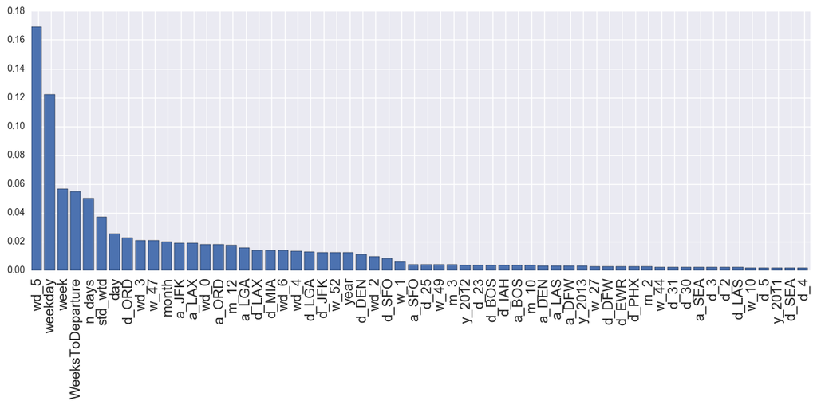

```python
plt.figure(figsize=(15, 5))

ordering = np.argsort(reg.feature_importances_)[::-1][:60]

importances = reg.feature_importances_[ordering]
feature_names = X_columns[ordering]

x = np.arange(len(feature_names))
plt.bar(x, importances)
plt.xticks(x + 0.5, feature_names, rotation=90, fontsize=15);
```

## Visualization of the results

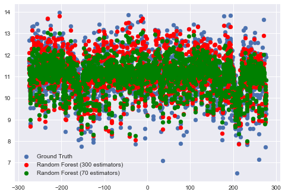

```python
#The features are projected on 1 dimension
pca = PCA(n_components=1)
X_proj = pca.fit_transform(X_test)

y_pred_reg = reg.predict(X_test)
plt.scatter(X_proj, y_test, label='Ground Truth')
plt.scatter(X_proj, y_pred_reg, color='r', label='Random Forest (300 estimators)')

y_pred_regrea = reg_rea.predict(X_test)

plt.scatter(X_proj, y_pred_regrea, color='g', label='Random Forest (70 estimators)')
plt.legend()
plt.show()
```

The more estimators we use, the more the Random Forest seems to discern fine details of the distribution.

## Gradient Boosting

```python
%%time

from sklearn.ensemble import GradientBoostingRegressor
gbr = GradientBoostingRegressor(n_estimators=200)

scores = cross_val_score(gbr, X_train, y_train, cv=5, scoring='neg_mean_squared_error')
print("Cross-validation score : {:.4f} +/-{:.4f}".format(
        np.mean(np.sqrt(-scores)), np.std(np.sqrt(-scores))))

gbr.fit(X_train, y_train)
y_pred = gbr.predict(X_test)
print("Score on test : {0}".format(np.sqrt(np.mean((y_pred-y_test)**2))))
```

```
Cross-validation score : 0.5181 +/-0.0082
Score on test : 0.5066202131123863
CPU times: user 39.2 s, sys: 441 ms, total: 39.6 s
Wall time: 41.2 s
```

## Extremely Randomized Trees

```python
%%time

from sklearn.ensemble import ExtraTreesRegressor
etr = ExtraTreesRegressor(n_estimators=10)

scores = cross_val_score(etr, X_train, y_train, cv=5, scoring='neg_mean_squared_error')
print("Cross-validation score : {:.4f} +/-{:.4f}".format(
        np.mean(np.sqrt(-scores)), np.std(np.sqrt(-scores))))

etr.fit(X_train, y_train)
y_pred = etr.predict(X_test)
print("Score on test : {0}".format(np.sqrt(np.mean((y_pred-y_test)**2))))
```

```
Cross-validation score : 0.4760 +/-0.0163
Score on test : 0.4418787301853383
CPU times: user 8.64 s, sys: 109 ms, total: 8.75 s
Wall time: 8.88 s
```

Introducing more randomeness as does the ExtraTreesRegressor yields a better score.

## Comparison of the two methods

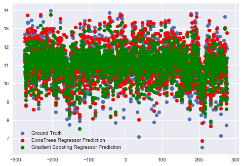

```python
#The features are projected on 1 dimension
pca = PCA(n_components=1)
X_proj = pca.fit_transform(X_test)

y_pred_etr = etr.predict(X_test)
plt.scatter(X_proj, y_test, label='Ground Truth')
plt.scatter(X_proj, y_pred_etr, color='r', label='ExtraTrees Regressor Prediction')

y_pred_gbr = gbr.predict(X_test)

plt.scatter(X_proj, y_pred_gbr, color='g', label='Gradient Boosting Regressor Prediction')
plt.legend()
plt.show()
```

There is no clear visual difference between those examples and the Random Forest with more than 200 estimators.

# Neural Networks

Let's try to find the best MLPRegressor with two hidden layers with a grid search on the number of units in each layer.

```python
from sklearn.neural_network import MLPRegressor
reg = MLPRegressor(hidden_layer_sizes=(50, 10), activation='tanh')

param_grid = {'hidden_layer_sizes': [(30, 10), (40, 10), (50, 10), (60, 10), (40, 15), (50, 15),
                                    (60, 15), (40, 20), (50, 20), (60, 20)]}
gdnn = GridSearchCV(reg, param_grid=param_grid, scoring='neg_mean_squared_error', verbose=1)

gdnn.fit(X_train, y_train)

y_pred = gdnn.predict(X_test)

print("Score on test : {0}".format(np.sqrt(np.mean((y_pred-y_test)**2))))
```

```
Fitting 3 folds for each of 10 candidates, totalling 30 fits
```

```
[Parallel(n_jobs=1)]: Done  30 out of  30 | elapsed:   38.7s finished
```

```
Score on test : 0.9886854731967109
```

```python
print(gdnn.best_params_)
```

```
{'hidden_layer_sizes': (40, 10)}
```

The multi layer perceptron performs really badly. It might be because features aren't scaled, which is mandatory for this kind of regression. Let's add a scaler to the pipeline.

```python
%%time

stdsca = StandardScaler()
nn = MLPRegressor(hidden_layer_sizes=(150, 50), activation='relu')
pipe_nn = Pipeline([('scaler', stdsca), ('mlp', nn)])

scores = cross_val_score(pipe_nn, X_train, y_train, cv=5, scoring='neg_mean_squared_error')
print("Cross-validation score : {:.4f} +/-{:.4f}".format(
        np.mean(np.sqrt(-scores)), np.std(np.sqrt(-scores))))

pipe_nn.fit(X_train, y_train)
y_pred = pipe_nn.predict(X_test)
print("Score on test : {0}".format(np.sqrt(np.mean((y_pred-y_test)**2))))
```

```
Cross-validation score : 0.5245 +/-0.0091
Score on test : 0.5002449745910986
CPU times: user 1min 13s, sys: 1.76 s, total: 1min 15s
Wall time: 38.7 s
```

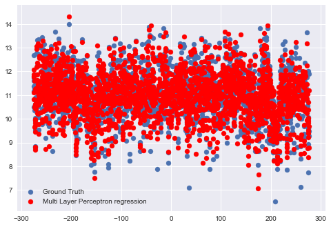

```python
#The features are projected on 1 dimension
pca = PCA(n_components=1)
X_proj = pca.fit_transform(X_test)

y_pred_nn = pipe_nn.predict(X_test)
plt.scatter(X_proj, y_test, label='Ground Truth')
plt.scatter(X_proj, y_pred_nn, color='r', label='Multi Layer Perceptron regression')

plt.legend()
plt.show()
```

This algorithm seems to perform very well since the deviation of the distribution seems to be conserved. But as the score shows, is isn't significantly better than the previous algorithms.

# Averaging vs. Boosting

## Simple decision tree

```python
%%time
from sklearn.tree import DecisionTreeRegressor
dtr = DecisionTreeRegressor()

scores = cross_val_score(dtr, X_train, y_train, cv=5, scoring='neg_mean_squared_error')
print("Cross-validation score : {:.4f} +/-{:.4f}".format(
        np.mean(np.sqrt(-scores)), np.std(np.sqrt(-scores))))

dtr.fit(X_train, y_train)
y_pred = dtr.predict(X_test)
print("Score on test : {0}".format(np.sqrt(np.mean((y_pred-y_test)**2))))
```

```
Cross-validation score : 0.6477 +/-0.0117
Score on test : 0.58332980432067
CPU times: user 1.44 s, sys: 43.4 ms, total: 1.48 s
Wall time: 1.49 s
```

The decision tree itself already gives a slightly better score than linear or ridge regression. Let's try improving the algorithm by using averaging and boosting, comparing the two methods.

## Averaging: bagging regressor with decision tree

```python
%%time
from sklearn.ensemble import BaggingRegressor
bgr = BaggingRegressor(DecisionTreeRegressor())

scores = cross_val_score(bgr, X_train, y_train, cv=5, scoring='neg_mean_squared_error')
print("Cross-validation score : {:.4f} +/-{:.4f}".format(
        np.mean(np.sqrt(-scores)), np.std(np.sqrt(-scores))))

bgr.fit(X_train, y_train)
y_pred = bgr.predict(X_test)
print("Score on test : {0}".format(np.sqrt(np.mean((y_pred-y_test)**2))))
```

```
Cross-validation score : 0.4811 +/-0.0141
Score on test : 0.4660798575986928
CPU times: user 8.12 s, sys: 278 ms, total: 8.4 s
Wall time: 8.54 s
```

## Boosting: adaboost with decision tree

```python
%%time
from sklearn.ensemble import AdaBoostRegressor
gbr = AdaBoostRegressor(DecisionTreeRegressor())

scores = cross_val_score(gbr, X_train, y_train, cv=5, scoring='neg_mean_squared_error')
print("Cross-validation score : {:.4f} +/-{:.4f}".format(
        np.mean(np.sqrt(-scores)), np.std(np.sqrt(-scores))))

gbr.fit(X_train, y_train)
y_pred = gbr.predict(X_test)
print("Score on test : {0}".format(np.sqrt(np.mean((y_pred-y_test)**2))))
```

```
Cross-validation score : 0.4527 +/-0.0119
Score on test : 0.43704602355189603
CPU times: user 49.8 s, sys: 595 ms, total: 50.4 s
Wall time: 51.3 s
```

Boosting using a decision tree estimator in an adaboost regressor gives a better score than a gradient boosting regressor. It also gives a slightly better result than averaging.

The previous section has shown that if we compare decision tree regressors, introducing more randomness gives a better score. Let's try an adaboost regressor with an extra trees regressor estimator.

**WARNING: The following cell may require a runtime of 5 minutes or more.**

```python
%%time
ade = AdaBoostRegressor(ExtraTreesRegressor())

scores = cross_val_score(ade, X_train, y_train, cv=5, scoring='neg_mean_squared_error')
print("Cross-validation score : {:.4f} +/-{:.4f}".format(
        np.mean(np.sqrt(-scores)), np.std(np.sqrt(-scores))))

ade.fit(X_train, y_train)
y_pred = ade.predict(X_test)
print("Score on test : {0}".format(np.sqrt(np.mean((y_pred-y_test)**2))))
```

```
Cross-validation score : 0.4115 +/-0.0125
Score on test : 0.38479518623647474
CPU times: user 6min 6s, sys: 5.26 s, total: 6min 12s
Wall time: 6min 28s
```

As expected, this combination gives the best score so far. However the training time is very long, compared to an AdaBoostRegressor with a DecisionTreeRegressor estimator or an ExtraTreesRegressor without boosting (which also gave a satisfying result).

## Comparison of boosting estimators

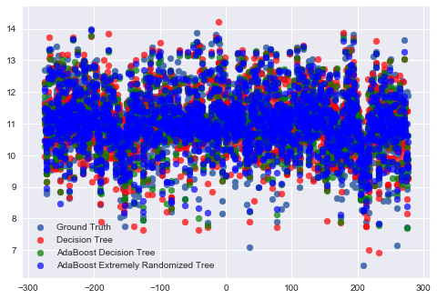

```python
#The features are projected on 1 dimension
pca = PCA(n_components=1)
X_proj = pca.fit_transform(X_test)

y_pred_dec = dtr.predict(X_test)
plt.scatter(X_proj, y_test, label='Ground Truth')
plt.scatter(X_proj, y_pred_dec, color='r', alpha=0.7,  label='Decision Tree')

y_pred_gbr = gbr.predict(X_test)
plt.scatter(X_proj, y_pred_gbr, color='g', alpha=0.7, label='AdaBoost Decision Tree')

y_pred_ade = ade.predict(X_test)
plt.scatter(X_proj, y_pred_ade, color='b', alpha=0.7, label='AdaBoost Extremely Randomized Tree')

plt.legend()
plt.show()
```

# Conclusion

[output not shown]

The scores may slightly change at each run of the notebook because of the randomness introduced by several of the regression methods.